# Oil volatility and sovereign risk of BRICS - ScienceDirect

## [Energy Economics](https://www.sciencedirect.com/journal/energy-economics)

[Volume 70](https://www.sciencedirect.com/journal/energy-economics/vol/70/suppl/C), February 2018, Pages 258-269

# Oil volatility and sovereign risk of BRICS

[Elie Bouri <sup>a</sup>](https://www.sciencedirect.com/author/55270146400/elie-i-bouri), [Syed Jawad Hussain Shahzad <sup>b</sup> <sup>c</sup>](https://www.sciencedirect.com/author/56365998900/syed-jawad-hussain-shahzad), , [David Roubaud <sup>b</sup>](https://www.sciencedirect.com/author/56046754600/david-roubaud)

https://doi.org/10.1016/j.eneco.2017.12.018[Get rights and content](https://s100.copyright.com/AppDispatchServlet?publisherName=ELS&contentID=S0140988317304383&orderBeanReset=true)

Full text access

## Highlights

- •

  Study dependence between crude oil implied volatility shocks and BRICS sovereign risk.
- •

  Examine spillovers in value-at-risk using multivariate regression quantile.
- •

  Oil volatility represents a common risk for oil-exporters and oil-importers.
- •

  Quantile impulse-response function: oil-exporters (oil-importers) are more sensitive to positive (negative) oil shocks.
- •

  Cross-quantilogram**:** low (high) volatility of oil predicts low (high) sovereign risk at various quantiles and lags.

## Abstract

We study the dependence between oil implied volatility shocks and [BRICS](https://www.sciencedirect.com/topics/social-sciences/india) sovereign risk from July 2009 to March 2017. First, we examine [spillovers](https://www.sciencedirect.com/topics/economics-econometrics-and-finance/spillover-effect) in value at risk using multivariate regression [quantiles](https://www.sciencedirect.com/topics/earth-and-planetary-sciences/quantile) and reveal that oil volatility represents a common risk for oil-exporting and oil-importing [BRICS](https://www.sciencedirect.com/topics/earth-and-planetary-sciences/republic-of-south-africa) countries. We also employ a quantile impulse-response function and reveal the presence of an asymmetry in the mechanisms of shock transmissions between oil exporters (Russia and Brazil) and oil importers (China and India): the former are more sensitive to positive oil shocks, whereas the latter are more sensitive to negative oil shocks. Second, we measure the directional predictability in the [quantiles](https://www.sciencedirect.com/topics/engineering/quantile) using the bivariate cross-quantilogram approach and show that in most cases, a low- (high-) volatility of oil market predicts low (high) sovereign risk at various quantiles and lags. Policy implications are discussed.

## JEL classification

C14

C32

G11

G15

## Keywords

Oil implied volatility

Sovereign risk

BRICS CDS

Cross-quantilogram

Quantile dependence

Spillover

## 1. Introduction

The globalization of markets has contributed to the increase in the demand for sovereign credit risk instruments, such as Credit Default Swap (CDS) which is a bilateral contract between a buyer and a seller where the buyer pays a periodic premium for insurance against a debt default. Typically, it applies to government and corporate bonds and is used by banks and hedge funds to hedge credit risk exposures, particularly in emerging economies that have low credit ratings, have not achieved a higher level of diversification, and still depend on energy exportation (UNDP, 2011). These features are also relevant to (some of) the large emerging markets that attract foreign institutional investors and portfolio managers whose primary focus is maximizing risk–return tradeoffs through diversification. A change in the sovereign risk quality can pose challenges for businesses and governmental bodies and, in particular, affect the re-weighting of international portfolios. Consequently, investors and [risk managers](https://www.sciencedirect.com/topics/agricultural-and-biological-sciences/risk-managers) would benefit from understanding the factors that affect sovereign credit risk.

While it is well documented that sovereign risk is affected by several key factors, such as [macroeconomic](https://www.sciencedirect.com/topics/economics-econometrics-and-finance/macroeconomics) instabilities, institutional quality of the country, external debt, foreign reserves, inflation, and economic growth, it can also be significantly affected by the volatility of oil prices, especially in large emerging economies. Bhar and Nikolova (2009) argue that emerging economies are more vulnerable to oil price volatility than [developed countries](https://www.sciencedirect.com/topics/engineering/developed-country) because they grow more rapidly and have more energy-intensive production structures.<sup>1</sup> In some emerging economies that are dependent on oil exportation, such as Russia, oil price volatility leads to [macroeconomic](https://www.sciencedirect.com/topics/social-sciences/macroeconomics) instabilities as well as to a volatility in export earnings, [foreign exchange reserves](https://www.sciencedirect.com/topics/economics-econometrics-and-finance/foreign-exchange-reserves), current account balances, economic activities, and eventually to difficulties in meeting debt obligations. Hilscher and Nosbusch (2010) argue that a country with historically higher macroeconomic volatility is more prone to default. Notably, an increase in the cost of government borrowing is reflected in higher CDS spreads and potentially leads to a sovereign debt default (Hilscher and Nosbusch, 2010). Hence, the effect of oil price volatility on sovereign credit risk can represent an important source of instabilities in macroeconomic fluctuations that both policy-makers and practitioners may want to respond to and consider (Liu et al., 2016). In particular, the recent sharp decrease in crude oil prices in late 2014 coupled with high oil price volatility has increased the focus on the oil-sovereign credit risk link. In 2015 and 2016, several press articles were released that demonstrated how falling oil prices and increasing oil volatility were closely linked to the quality of sovereign credit risk, especially in heavily-oil-dependent economies, such as Russia, that are strained in funding their public budget and paying off their external dollar-denominated debt. Although several studies consider the predictive power of oil prices – which are part of commodities prices – in modeling the sovereign yield spread in emerging economies (Longstaff et al., 2011; Amstad et al., 2016; Aizenman et al., 2016), the effect of oil price volatility<sup>2</sup> on sovereign CDS spreads remains extremely understudied. Against this background, the aim of this study is to examine the dependence between oil price volatility and BRICS<sup>3</sup> sovereign risk using a rich and dynamic approach that is capable of capturing upside and downside risk [spillovers](https://www.sciencedirect.com/topics/economics-econometrics-and-finance/spillover-effect) from oil volatility to BRICS CDS spreads and measuring within a cross-quantilogram (CQ) bivariate model the predictability of BRICS sovereign risk based on oil volatility in the quantiles. Our choice for large emerging countries, i.e. BRICS, stems from the heterogeneity of this group, inclusive of both large oil-importing countries (China and India) and large oil-exporting countries (such as Russia), and therefore the possibility to uncover through our empirical analyses any significant differences in the impact of oil price volatility on the sovereign risk between oil-exporting and oil-importing countries.<sup>4</sup>

Our study is related to the limited empirical literature on the oil volatility-sovereign risk link (Sharma and Thuraisamy, 2013; Liu et al., 2016; Bouri et al., 2017a; Lee et al., 2017). Importantly, it addresses several shortcomings and explores new empirical grounds. Sharma and Thuraisamy (2013) highlight the role of oil price volatility in predicting sovereign CDS returns in six Asian countries (Indonesia, [Japan](https://www.sciencedirect.com/topics/engineering/japan), Malaysia, the Philippines, [South Korea](https://www.sciencedirect.com/topics/social-sciences/south-korea) and Vietnam). However, they overlook the effect of oil uncertainty on BRICS sovereign risk and more importantly do not account for the codependence between sovereign risk and oil implied volatility in the different quantiles. Liu et al. (2016) focus on the statistical properties of country risk rating in oil-exporting countries and show that oil price volatility can accentuate the volatility of country risk ratings. The authors cover only oil-exporting countries within their analysis and use relatively low-frequency (monthly) data on country risk from the International Country Risk Guide. In addition, their focus is limited to the mean-based relationships between the examined variables. Lee et al. (2017) show that country risk in net oil-importing (Germany, France, Italy, [Japan](https://www.sciencedirect.com/topics/social-sciences/japan) and US) and net oil-exporting countries (Canada, UK) is affected by oil price shocks. However, the authors overlook, among other things, oil importers and oil exporters from BRICS as well as the effect of oil (implied) volatility shocks across the quantiles. As indicated by several studies (e.g., Ville and Wicken, 2012; Holden, 2013), advanced economies have achieved higher level of diversification, have an AAA credit rating, and have escaped the so-called “resource curse”, which suggests that the examination of the oil volatility-sovereign risk in emerging economies is more relevant. Bouri et al. (2017a) use a GARCH-based measure of oil volatility and concentrate on the average causal relationship between the volatilities of energy commodities and CDS spreads without taking into account the difference in the dependence between high and low quantiles. It is documented that the return and volatility distribution of assets is most often heterogeneous, which suggests that it is appropriate to use a quantile-based approach to uncover differences in the response of sovereign risk to oil volatility shocks across the different quantiles. We follow the recently proposed methodology of White et al. (2015) and address this empirical gap. White et al. (2015) proposed an interesting model called VAR for VaR – that is, vector autoregressive (VAR) for value at risk (VaR) – that can assess the codependence between BRICS sovereign CDS spreads and oil implied volatility. Their proposed model contains multivariate regression quantiles that overcome the need for strong distributional assumptions given that it directly models the (stationary) series. Compared to univariate quantile models, it uncovers richer dynamics, and it allows for estimating a [VAR process](https://www.sciencedirect.com/topics/earth-and-planetary-sciences/autoregressive-process) on the quantiles of the stationary series – in our case, CDS spreads and oil implied volatility – rather on the mean. By applying the VAR for VaR, we can also focus on the upside and downside risk spillovers from oil volatility to BRICS CDS spreads and calculate pseudo quantile impulse-response functions (QIRF). Finally, we apply the CQs of Han et al. (2016) to capture the directional quantile predictability of BRICS CDS spreads based on oil implied volatility.<sup>5</sup> The adopted empirical methods enrich our analysis by implicitly accounting for the impact of the large volatility experienced by the oil market during the European debt crisis of 2010–13 and oil slump of mid-2014 on BRICS sovereign risk.

In assessing the vulnerability – or, alternatively, the resistance – of BRICS sovereign risk to oil uncertainty, we seek to uncover BRICS's economic heterogeneity vis-à-vis oil market volatility. This is relevant to the structure of our sample, which covers two major importers and consumers of crude oil (China and India) and one of the leading oil producers and exporters (Russia).<sup>6</sup> Intuitively, the effect of volatility price shocks on sovereign risk should be larger in oil-exporting countries than in oil-importing countries.

The study is organized as follows. The next section provides an overview of the related literature, Section 3 presents the [econometric](https://www.sciencedirect.com/topics/economics-econometrics-and-finance/econometrics) techniques that we employ, and Section 4 describes the data and presents the empirical results. Finally, Sections 5 concludes.

## 2. Literature review

In this section, we explore two main strands of research that are closely related to the focus of our study. The first is price discovery in the sovereign CDS market. The second is the effect of oil implied volatility on financial variables.

Along with globalization and the rising importance of the sovereign CDS in mitigating credit risk, numerous studies have attempted to understand the determinants of sovereign CDS spreads in large emerging countries that attract important international capital. Some studies focus on the role played by commodities, including crude oil. Longstaff et al. (2011) show that oil and commodity price changes are among the main contributors to the sovereign CDS spreads of 26 developed and emerging-market countries. Aizenman et al. (2016) concentrate on the sovereign risk of emerging markets and show that the [commodity term of trade](https://www.sciencedirect.com/topics/economics-econometrics-and-finance/terms-of-trade) volatility is positively associated with sovereign CDS spreads. Few other studies include the impact of oil prices while modeling sovereign spreads. Duffie et al. (2003) show that Russia's credit risk responds to political events and is negatively correlated with the country's foreign currency reserves and oil prices. Alexandre and de Benoist (2010) examine the impact of oil price returns and volatility on bond risk premiums in seventeen emerging countries from 1998 to 2008. The authors stress the important role played by oil price return and volatility in determining sovereign credit risk, especially in oil-exporting countries (i.e., Russia and Brazil). Fonseca et al. (2016) stress the importance of volatility and jumps extracted from the oil futures in explaining CDS spread changes in the energy sector. Sharma and Thuraisamy (2013) focus on six Asian countries (Indonesia, [Japan](https://www.sciencedirect.com/topics/engineering/japan), Malaysia, the Philippines, [South Korea](https://www.sciencedirect.com/topics/social-sciences/south-korea) and Vietnam) and find that oil price uncertainty can be used as a predictor for CDS returns in several cases. Instead, we concentrate on the effect of oil volatility, as measured by the CBOE oil implied volatility index (OVX), on the volatility of CDS spreads. Hooper (2015) examines the association between oil and gas reserves and sovereign spreads in 10 emerging oil-exporting countries from 1994 to 2014. The author shows that oil reserves have an effect on sovereign spreads but that this effect also depends on the institutional quality of the country, which is determined by its corruption, political stability, and democracy. Liu et al. (2016) incorporate the variable of oil price volatility into the theoretical framework of Cruces (2006) and find that the statistical properties of country risk among oil-exporting countries remain steady despite oil price volatility. Remarkably, the authors show that oil price volatility can accentuate the volatility of country risk ratings. Lee et al. (2017) use a structural VAR approach to analyze monthly data and show that country risk in net oil-importing (Germany, France, Italy, [Japan](https://www.sciencedirect.com/topics/social-sciences/japan) and US) and net oil-exporting countries (Canada, UK) is affected by oil price shocks. We instead focus on sovereign risk, as measured by CDS spreads, using a daily dataset. We also account for the impact of oil volatility on the different quantiles of sovereign risk. In an interesting paper, Bouri et al. (2017a) explicitly examine the volatility transmission from commodity and energy indices to sovereign CDS spreads in emerging and frontier economies. Based on a causality-in-variance test, the authors reveal that the volatility transmission from commodities to CDS spreads is not clear cut as it does not depend solely on commodity and energy dependence. However, Bouri et al. (2017a) do not differentiate between upper and lower tail dependence in the dynamics of the causality in variance, but they instead focus only on a mean-based measure of volatility linkages. We contribute to the finance literature by uncovering the tail interdependence between oil implied volatility and sovereign CDS spreads of BRICS countries under different market conditions (i.e., in lower, median, and upper quantiles), considering for the response of CDS sovereign risk to oil volatility shocks using quantile IRFs (White et al., 2015).

Given our reliance on implied volatility, which is a forward-looking measure of volatility, we also focus on the directional predictability from the perspective of investors' expectations of oil volatility within the predictive approach of Han et al. (2016), which allows for measuring directional predictability in quantiles from oil implied volatility to BRICS sovereign risk.

In contrast to prior studies, which usually use a backward-looking proxy of volatility such as absolute returns, squared returns, or GARCH-based estimates, we employ the market's expectations of 30-day volatility based on option data. In addition to historical volatility information, implied volatility reflects investors' expectations of future market conditions. Given that market participants are more concerned with future volatility measures than historical volatility measures, the inclusion of implied volatility enriches our empirical analysis. Recently, the impact of the CBOE OVX on some other financial variables has been the subject of a few studies. Liu et al. (2013) focus on the short- and long-run relationships between the implied volatility of oil and that of US equities, the euro/dollar exchange rate, and gold prices. Maghyereh et al. (2016) use implied volatility indices within the oil volatility-stock nexus. Bouri et al. (2017b) examine the effect of the implied volatility of oil on that of gold and Indian equities. As shown, implied oil volatility has not been applied in the oil volatility-sovereign risk nexus. Sharma and Thuraisamy (2013) examine the effect of oil uncertainty on CDS spreads, but they rely on the rolling variance of oil returns as a proxy for oil price uncertainty. We contribute to the related literature by using oil implied volatility data within the recently introduced approaches of White et al. (2015) and Han et al. (2016), which are explained in the following section.

## 3. Employed methodologies

This study applies White et al.'s (2015) VAR for VaR model to study the degree of tail dependence between BRICS sovereign CDS spreads and the OVX. This [econometric](https://www.sciencedirect.com/topics/economics-econometrics-and-finance/econometrics) technique appears particularly suitable for studying sovereign risk reactions to oil volatility shocks by examining the pseudo impulse-response functions (IRFs), which allow for distinguishing between the reaction of sovereign risk to upper and lower quantile events. It is important to note that the multivariate quantile regression of White et al. (2015), the so-called VAR for VaR, allows estimating the tail dependence among the [random variables](https://www.sciencedirect.com/topics/engineering/random-variable-xi) of interest directly rather than recovering it indirectly via models of time-varying first and second moments as in the case of GARCH based models. Additionally, the multivariate regression quantiles overcomes the need for strong distributional assumptions as it directly models the (stationary) series. Although copula functions can model the dependence structure and provide information on the probability that two variables jointly experience extreme upwards or downwards movements, the application of copula functions is usually carried out based on Inference Function for Margins (IFS). Notably, the fitting of the marginal model requires care because if the model is unable to explain the [time series](https://www.sciencedirect.com/topics/social-sciences/time-series) variations, the residual (standardized residual) used in the copula estimation may provide spurious results (under/over fitting parameters). Furthermore, the approach of White et al. (2015) allows for the construction of pseudo impulse-response functions for the quantiles of the CDS spreads in BRICS in order to examine how oil volatility shocks are absorbed.

To measure the predictability of BRICS sovereign risk through OVX, we use bivariate CQ of Han et al. (2016). This technique provides a sample estimate of the measure of lead/lag dependence in quantiles and a corresponding test about directional predictability in quantiles from one series to another. Importantly, the CQs of Han et al. (2016) allows for capturing the directional quantile predictability of BRICS CDS spreads based on oil implied volatility in different quantiles, which cannot be captured by copula.

Detailed description of the above-mentioned methods is available in the Appendix.

## 4. Empirical findings

### 4.1. Data description

The data set used in this study consists of the daily price of the CBOE implied volatility index of crude oil (OVX) and the 5-year CDS spreads in Brazil, Russia, India, China, South Africa (BRICS) countries. An implied volatility index, such as the OVX, reflects both historical volatility information and investors' expectation on future market conditions (Liu et al., 2013). Accordingly, the OVX represents a forward-looking measure of oil market uncertainty. The CDS spread for the 5-year maturity contract is used as it represents the most traded and liquid contract. Data were collected from Thomson Reuters DataStream for the period from July 01, 2009, to March 31, 2017, for a total of 2023 daily observations. The beginning of the period starts just after the end of the US recession, as defined by the National Bureau [of Economic Research](https://www.sciencedirect.com/topics/social-sciences/economics-of-science) (NBER), in order to ensure that the [global financial crisis](https://www.sciencedirect.com/topics/engineering/global-financial-crisis) does not overlap with our sample period.

Table 1 presents the summary statistics of BRICS sovereign CDS spreads and OVX changes. The mean value of each country's CDS spread is higher than the mean value of OVX. The OVX [standard deviation](https://www.sciencedirect.com/topics/economics-econometrics-and-finance/measure-of-dispersion) reflects different behaviour in each CDS market; it is highest (lowest) in Brazil (China), and it is smaller than that of CDS spreads. Furthermore, the results from two unit root tests (Augmented Dickey-Fuller and Kwiatkowski, Phillips, Schmidt, and Shin) show that all series are stationary at first differenced and hence we used the first difference of OVX and CDS spreads for econometric analysis.

Table 1. [Descriptive statistics](https://www.sciencedirect.com/topics/economics-econometrics-and-finance/descriptive-statistics) and unit root properties.

| Empty Cell | Mean | Std. dev. | Skewness | Kurtosis | ADF | ADF (∆) | KPSS | KPSS (∆) |
| --- | --- | --- | --- | --- | --- | --- | --- | --- |
| OVX | 34.645 | 10.949 | 0.507 | 3.269 | −3.3781<sup>⁎⁎</sup> | −29.20<sup>⁎⁎⁎</sup> | 0.6134<sup>⁎⁎</sup> | 0.0412 |
| Brazil | 189.50 | 93.903 | 1.550 | 4.777 | −1.413 | −23.29<sup>⁎⁎⁎</sup> | 3.5263<sup>⁎⁎⁎</sup> | 0.0941 |
| Russia | 221.08 | 85.490 | 1.690 | 6.641 | −2.628<sup>⁎⁎⁎</sup> | −29.45<sup>⁎⁎⁎</sup> | 1.6280<sup>⁎⁎⁎</sup> | 0.0786 |
| India | 220.39 | 71.324 | 0.748 | 2.983 | −1.733 | −27.36<sup>⁎⁎⁎</sup> | 0.8688<sup>⁎⁎⁎</sup> | 0.1152 |
| China | 92.877 | 23.411 | 0.752 | 3.310 | −3.111<sup>⁎⁎</sup> | −26.91<sup>⁎⁎⁎</sup> | 0.9739<sup>⁎⁎⁎</sup> | 0.0331 |
| SA | 188.89 | 53.159 | 1.081 | 4.107 | −2.820<sup>⁎</sup> | −40.34<sup>⁎⁎⁎</sup> | 3.5619<sup>⁎⁎⁎</sup> | 0.0694 |

Note: Std. dev. stands for standard deviations. ADF and KPSS are empirical statistics of the Augmented Dickey and Fuller (1979) unit root tests and the Kwiatkowski et al. (1992) stationarity test, respectively. ∆ indicates that the series are first differenced.

**⁎⁎⁎**

Denotes the rejection of the null hypotheses of unit root and stationarity at the 1% level.

**⁎⁎**

Denotes the rejection of the null hypotheses of unit root and stationarity at the 5% level.

**⁎**

Denotes the rejection of the null hypotheses of unit root and stationarity at the 10% level.

Fig. 1 displays the time trends in BRICS sovereign CDS spreads and OVX. The sovereign CDS spreads of Brazil, Russia and South Africa exhibit a spectacular rise starting in mid-2014, when oil prices sharply decline, and peak during 2015–16. The OVX exhibits similar behaviour during this period. The sovereign CDS spreads of India and China experience a steady increase during the European debt crisis of 2010–13. This crisis also adversely affects Russia's sovereign risk given the strong economic ties between Russia and Europe.

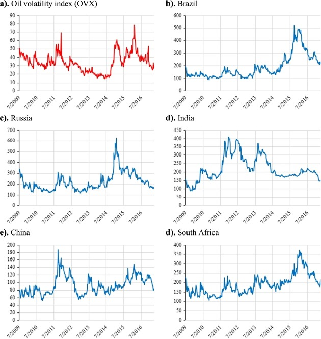

Fig. 1. Time trend of [BRICS](https://www.sciencedirect.com/topics/earth-and-planetary-sciences/republic-of-south-africa) sovereign [CDS](https://www.sciencedirect.com/topics/economics-econometrics-and-finance/credit-derivative) spreads and oil volatility index.

### 4.2. Results from the VAR for VaR approach<sup>7</sup>

The estimates and standard errors for VAR for VaR are presented in Table 2, where the downside spillover (when *q* = 0.05) and the upside spillover (when *q* = 0.95) are displayed, respectively, in panels A and B. Each VAR structure relates the conditional quantile of oil volatility to the quantiles of CDS spread and vice versa. The upside and downside quantiles are explained by the predicators (parameters, e.g., *a*<sub>11</sub> and *a*<sub>12</sub>) as well as the pairs (*a*<sub>21</sub> and *a*<sub>22</sub>) of the first and second equations, respectively. To measure the tail dependence between oil volatility and BRICS sovereign CDS spreads, each quantile is expressed in terms of off-diagonal matrices *b*<sub>12</sub> and *b*<sub>21</sub>; therefore, the null hypothesis of tail dependence is assessed by testing *b*<sub>12</sub> = *b*<sub>21</sub> = 0. The values of the diagonal autoregressive coefficients (*b*<sub>11</sub> and *b*<sub>22</sub>) are near unity and are statistically significant. This implies that VaR processes are autocorrelated, a finding that is in line with the reported literature that used the CAViaR models (see, e.g., White et al., 2015).

Table 2. Estimates and standard errors for VAR for VaR.

| Panel A: Downside spillovers (*q* = 0.05) |  |  |  |  | Panel B: Upside spillovers (*q* = 0.95) |  |  |  |  |
| --- | --- | --- | --- | --- | --- | --- | --- | --- | --- |
| a). Brazil |  |  |  |  |  |  |  |  |  |
| *c*<sub>1</sub> | *a*<sub>11</sub> | *a*<sub>12</sub> | *b*<sub>11</sub> | *b*<sub>12</sub> | *c*<sub>1</sub> | *a*<sub>11</sub> | *a*<sub>12</sub> | *b*<sub>11</sub> | *b*<sub>12</sub> |
| −0.216<sup>⁎</sup> | −0.236<sup>⁎⁎</sup> | −0.164<sup>⁎⁎⁎</sup> | 0.873<sup>⁎⁎⁎</sup> | −0.118 | 0.146<sup>⁎</sup> | 0.167<sup>⁎⁎⁎</sup> | 0.013 | 0.921<sup>⁎⁎⁎</sup> | −0.053 |
| (0.116) | (0.093) | (0.052) | (0.060) | (0.083) | (0.082) | (0.047) | (0.091) | (0.020) | (0.063) |
| *c*<sub>2</sub> | *a*<sub>21</sub> | *a*<sub>22</sub> | *b*<sub>21</sub> | *b*<sub>22</sub> | *c*<sub>2</sub> | *a*<sub>21</sub> | *a*<sub>22</sub> | *b*<sub>21</sub> | *b*<sub>22</sub> |
| −0.053<sup>⁎⁎</sup> | 0.003 | −0.190<sup>⁎⁎⁎</sup> | 0.085<sup>⁎⁎⁎</sup> | 0.842<sup>⁎⁎⁎</sup> | 0.129<sup>⁎⁎⁎</sup> | 0.000 | 0.187<sup>⁎⁎⁎</sup> | 0.041<sup>⁎⁎⁎</sup> | 0.868<sup>⁎⁎⁎</sup> |
| (0.023) | (0.010) | (0.043) | (0.007) | (0.034) | (0.050) | (0.008) | (0.042) | (0.004) | (0.034) |
| b). Russia |  |  |  |  |  |  |  |  |  |
| *c*<sub>1</sub> | *a*<sub>11</sub> | *a*<sub>12</sub> | *b*<sub>11</sub> | *b*<sub>12</sub> | *c*<sub>1</sub> | *a*<sub>11</sub> | *a*<sub>12</sub> | *b*<sub>11</sub> | *b*<sub>12</sub> |
| −0.469 | −0.492<sup>⁎⁎⁎</sup> | −0.560<sup>⁎⁎</sup> | 0.734<sup>⁎⁎⁎</sup> | −0.181 | 0.993<sup>⁎⁎⁎</sup> | 0.171<sup>⁎⁎⁎</sup> | 0.801<sup>⁎⁎⁎</sup> | 0.905<sup>⁎⁎⁎</sup> | −0.627<sup>⁎⁎⁎</sup> |
| (0.335) | (0.162) | (0.334) | (0.094) | (0.265) | (0.352) | (0.059) | (0.169) | (0.031) | (0.182) |
| *c*<sub>2</sub> | *a*<sub>21</sub> | *a*<sub>22</sub> | *b*<sub>21</sub> | *b*<sub>22</sub> | *c*<sub>2</sub> | *a*<sub>21</sub> | *a*<sub>22</sub> | *b*<sub>21</sub> | *b*<sub>22</sub> |
| −0.064<sup>⁎⁎⁎</sup> | −0.008<sup>⁎</sup> | −0.207<sup>⁎⁎⁎</sup> | 0.084<sup>⁎⁎⁎</sup> | 0.868<sup>⁎⁎⁎</sup> | 0.162<sup>⁎</sup> | 0.014 | 0.166<sup>⁎⁎⁎</sup> | 0.045<sup>⁎⁎⁎</sup> | 0.876<sup>⁎⁎⁎</sup> |
| (0.020) | (0.004) | (0.042) | (0.005) | (0.027) | (0.087) | (0.009) | (0.057) | (0.003) | (0.050) |
| c). India |  |  |  |  |  |  |  |  |  |
| *c*<sub>1</sub> | *a*<sub>11</sub> | *a*<sub>12</sub> | *b*<sub>11</sub> | *b*<sub>12</sub> | *c*<sub>1</sub> | *a*<sub>11</sub> | *a*<sub>12</sub> | *b*<sub>11</sub> | *b*<sub>12</sub> |
| 0.004 | −0.058<sup>⁎⁎⁎</sup> | −0.001 | 0.979<sup>⁎⁎⁎</sup> | 0.000 | 0.107 | 0.183 | 0.235 | 0.923<sup>⁎⁎⁎</sup> | −0.117 |
| (0.086) | (0.016) | (0.078) | (0.011) | (0.066) | (0.636) | (0.115) | (0.273) | (0.088) | (0.258) |
| *c*<sub>2</sub> | *a*<sub>21</sub> | *a*<sub>22</sub> | *b*<sub>21</sub> | *b*<sub>22</sub> | *c*<sub>2</sub> | *a*<sub>21</sub> | *a*<sub>22</sub> | *b*<sub>21</sub> | *b*<sub>22</sub> |
| −0.073<sup>⁎⁎⁎</sup> | −0.002 | −0.169<sup>⁎⁎⁎</sup> | −0.005<sup>⁎</sup> | 0.887<sup>⁎⁎⁎</sup> | 0.098<sup>⁎</sup> | 0.002 | 0.191<sup>⁎⁎⁎</sup> | −0.006 | 0.887<sup>⁎⁎⁎</sup> |
| (0.020) | (0.004) | (0.039) | (0.002) | (0.024) | (0.061) | (0.010) | (0.055) | (0.007) | (0.036) |
| d). China |  |  |  |  |  |  |  |  |  |
| *c*<sub>1</sub> | *a*<sub>11</sub> | *a*<sub>12</sub> | *b*<sub>11</sub> | *b*<sub>12</sub> | *c*<sub>1</sub> | *a*<sub>11</sub> | *a*<sub>12</sub> | *b*<sub>11</sub> | *b*<sub>12</sub> |
| −0.164<sup>⁎</sup> | −0.244<sup>⁎⁎⁎</sup> | −0.118 | 0.856<sup>⁎⁎⁎</sup> | −0.069 | 0.244<sup>⁎</sup> | 0.203 | 0.223<sup>⁎⁎⁎</sup> | 0.874<sup>⁎⁎⁎</sup> | −0.112<sup>⁎</sup> |
| (0.087) | (0.062) | (0.112) | (0.047) | (0.073) | (0.133) | (0.179) | (0.064) | (0.102) | (0.070) |
| *c*<sub>2</sub> | *a*<sub>21</sub> | *a*<sub>22</sub> | *b*<sub>21</sub> | *b*<sub>22</sub> | *c*<sub>2</sub> | *a*<sub>21</sub> | *a*<sub>22</sub> | *b*<sub>21</sub> | *b*<sub>22</sub> |
| −0.065<sup>⁎⁎⁎</sup> | −0.027 | −0.191<sup>⁎⁎⁎</sup> | −0.015 | 0.875<sup>⁎⁎⁎</sup> | 0.092 | −0.055<sup>⁎</sup> | 0.201<sup>⁎⁎⁎</sup> | 0.048<sup>⁎</sup> | 0.828<sup>⁎⁎⁎</sup> |
| (0.025) | (0.026) | (0.050) | (0.014) | (0.033) | (0.080) | (0.030) | (0.036) | (0.019) | (0.046) |
| e). South Africa |  |  |  |  |  |  |  |  |  |
| *c*<sub>1</sub> | *a*<sub>11</sub> | *a*<sub>12</sub> | *b*<sub>11</sub> | *b*<sub>12</sub> | *c*<sub>1</sub> | *a*<sub>11</sub> | *a*<sub>12</sub> | *b*<sub>11</sub> | *b*<sub>12</sub> |
| −0.446<sup>⁎⁎</sup> | −0.277<sup>⁎⁎⁎</sup> | −0.421<sup>⁎⁎⁎</sup> | 0.802<sup>⁎⁎⁎</sup> | −0.176<sup>⁎⁎</sup> | 0.718 | 0.244<sup>⁎⁎⁎</sup> | 0.365 | 0.773<sup>⁎⁎⁎</sup> | −0.011 |
| (0.180) | (0.067) | (0.059) | (0.053) | (0.085) | (0.545) | (0.050) | (0.275) | (0.049) | (0.357) |
| *c*<sub>2</sub> | *a*<sub>21</sub> | *a*<sub>22</sub> | *b*<sub>21</sub> | *b*<sub>22</sub> | *c*<sub>2</sub> | *a*<sub>21</sub> | *a*<sub>22</sub> | *b*<sub>21</sub> | *b*<sub>22</sub> |
| −0.040<sup>⁎⁎</sup> | −0.002 | −0.189<sup>⁎⁎⁎</sup> | 0.047<sup>⁎⁎⁎</sup> | 0.859<sup>⁎⁎⁎</sup> | 0.136<sup>⁎</sup> | −0.001 | 0.189<sup>⁎⁎⁎</sup> | 0.055<sup>⁎⁎⁎</sup> | 0.848<sup>⁎⁎⁎</sup> |
| (0.022) | (0.009) | (0.039) | (0.007) | (0.029) | (0.083) | (0.015) | (0.043) | (0.019) | (0.051) |

The results derived from the VAR for VaR regression are further enriched through a visual inspection of the impact of OVX quantiles on the lowest and highest quantiles of CDS spreads. The upside and downside standard VaR of CDS spreads and the VAR for VaR from OVX for both lower and upper quantiles are presented in Fig. 2. A careful investigation of the VaR and VAR for VaR plots reveals that the curves follow a homogenous pattern over the whole period. The upside/downside VaR curves of the CDS spread exhibit similar sequences of boom and busts in each market. For Brazil and Russia, CDS spreads show successive peaks during 2014–15, when oil prices plunge sharply. In contrast, India, China and South Africa show successive peaks during the European debt crisis of 2010–13. The VAR for VaR values are higher than the VaRs (for both lower and upper quantiles), and hence, a significant spillover from oil volatility to sovereign risk is evident.

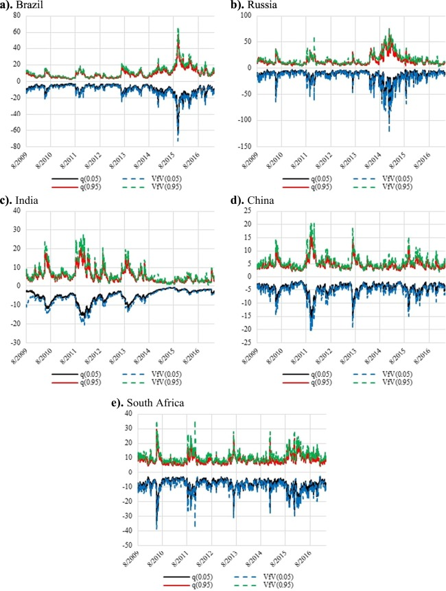

Fig. 2. Lowest and highest [quantiles](https://www.sciencedirect.com/topics/earth-and-planetary-sciences/quantile) of [CDS](https://www.sciencedirect.com/topics/economics-econometrics-and-finance/credit-derivative) spread changes and impact of OVX [quantiles](https://www.sciencedirect.com/topics/engineering/quantile).

Note: These figures show 5% value at risk (VaR) of the [BRICS](https://www.sciencedirect.com/topics/earth-and-planetary-sciences/republic-of-south-africa) sovereign CDS spread and 5% VAR for VaR from the oil volatility (OVX).

### 4.3. Results from the pseudo QIRFs

Furthermore, we present in Fig. 3 the IRF of sovereign CDS spread changes to OVX using pseudo impulse response. Contrary to the standard IRF, which provides only the reaction of one market shock to another market, the pseudo IRF allows for distinguishing between the reaction of a market to extreme (measured by upper quantiles) and tail (measured by lower quantiles) events. The lower and upper quantiles of oil volatility and sovereign risk show low and high uncertainty (risk), respectively. The horizontal axis reflects the time in days, while the vertical axis reflects the amplitude of the CDS spread's response to the OVX. The pseudo IRF tracks how the OVX negative/positive changes propagate through the BRICS sovereign CDS spread changes and how long it takes for BRICS sovereign CDS spread changes to completely absorb the OVX changes. Thus, the shock is completely absorbed when the curves merge entirely with the horizontal axis, i.e., converge to zero.

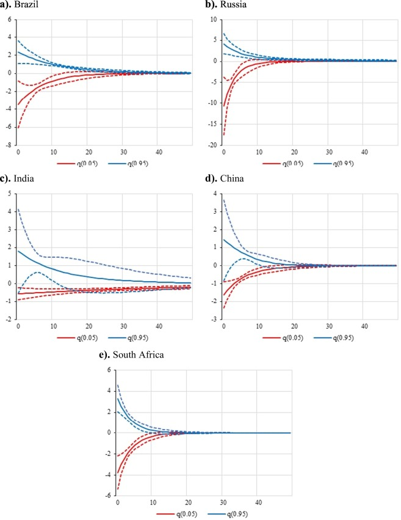

Fig. 3. Impulse-response functions of sovereign CDS spread change to oil volatility index.

Note: The above figures show the pseudo quantile impulse-response functions for lowest (0.05) and upper (0.95) quantile-levels along with respective 95% confidence intervals. The magnitude of response is on y-axis while the period in days is on x-axis. These quantile impulse responses are drawn from a bivariate VAR for VaR and show how quantiles of SCDS spreads response to oil volatility shocks.

Table 3. Descriptive statics of VaR of BRICS CDS and VAR for VaR from oil market.

| Panel A): Downside spillovers *q*(0.05) | Panel A): Downside spillovers VfV(0.05 | Panel A): Downside spillovers *H*<sub>0</sub> = *q*(0.05) = VfV(0.05) *H*<sub>1</sub> = *q*(0.05) > VfV(0.05) | Panel B: Upside spillovers *q*(0.95) | Panel B: Upside spillovers VfV(0.95) | Panel B: Upside spillovers *H*<sub>0</sub> = *q*(0.95) = VfV(0.95) *H*<sub>1</sub> = *q*(0.95) < VfV(0.95) |
| --- | --- | --- | --- | --- | --- |
| *a). Brazil* |  |  |  |  |  |
| −9.172 | −11.966 | 0.153 | 9.522 | 10.294 | 0.115 |
| (6.075) | (7.502) | [0.000] | (6.219) | (7.091) | [0.000] |
| *b). Russia* |  |  |  |  |  |
| −13.317 | −17.183 | 0.175 | 13.994 | 16.308 | 0.156 |
| (10.481) | (12.711) | [0.000] | (9.396) | (10.686) | [0.000] |
| *c). India* |  |  |  |  |  |
| −5.085 | −6.301 | 0.185 | 5.491 | 6.737 | 0.139 |
| (3.293) | (3.987) | [0.000] | (3.790) | (4.919) | [0.000] |
| *d). China* |  |  |  |  |  |
| −4.405 | −5.330 | 0.210 | 4.803 | 5.847 | 0.212 |
| (2.162) | (2.742) | [0.000] | (1.921) | (2.762) | [0.000] |
| *e). South Africa* |  |  |  |  |  |
| −8.367 | −10.902 | 0.179 | 8.938 | 9.903 | 0.143 |
| (3.803) | (4.543) | [0.000] | (3.156) | (4.017) | [0.000] |

Note: This table reports the quantile values and VAR for VaR of the sovereign CDS spread changes from the oil volatility index. Values in brackets are standard errors, and values in brackets are the p-values of the KS test.

### 4.4. Results from the bivariate CQ<sup>9</sup>

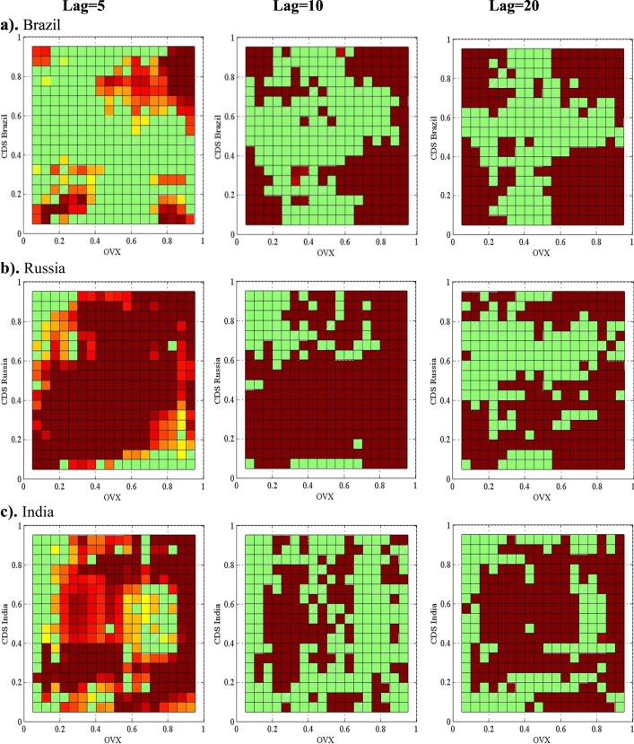

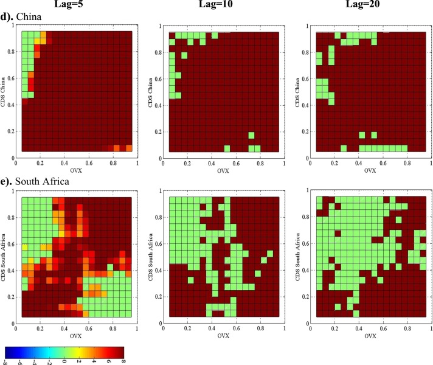

Fig. 4. Directional causality in quantiles from oil volatility (OVX) to BRICS sovereign CDS.

Moreover, the CQs of Brazil, Russia and South Africa show some green coloured areas located on the upper left and lower right corners that can be interpreted as a weak dependence between the oil and sovereign markets when the two markets are in different states (one market is bullish, while the other is bearish). Overall, the [graphical results](https://www.sciencedirect.com/topics/engineering/graphical-result) drawn from the cross-quantilogram approach highlight the ability of oil volatility to predict the sovereign risk of BRICS.

Distinguishing our study from prior studies via two novel quantile-based approaches – the multivariate quantile regression of White et al. (2015) and the directional quantile predictability of Han et al. (2016) – we reported more nuanced findings by uncovering the impact of oil implied volatility on BRICS CDS spreads in different quantiles. Specifically, we moved beyond the mean-based causality measures of Bouri et al. (2017a) and accounted for the difference in the impact of oil volatility on sovereign risk across lower, middle, and upper quantiles. Our findings nicely complement the findings from Sharma and Thuraisamy (2013) who overlooked the effect of oil uncertainty on BRICS sovereign risk – although BRICS include some of the largest oil exporters and oil importers – and focused only on six Asian countries (Indonesia, Japan, Malaysia, the Philippines, South Korea and Vietnam). We extended the work of Amstad et al. (2016) by focusing on the direct role of oil volatility, as a global [risk factor](https://www.sciencedirect.com/topics/economics-econometrics-and-finance/risk-factor), in explaining the sovereign CDS spread changes while differentiating between BRICs oil-importers and oil-exporters. Our findings also added to Lee et al. (2017) who considered only advanced economies and thus overlooked large emerging economics that are more dependent on energy commodities. While Liu et al. (2016) show that oil price volatility can accentuate the volatility of country risk ratings, we revealed that downward and upward changes in oil volatility can predict, respectively, the low and high CDS spreads.

## 5. Conclusion

The above findings are useful for policy-directed research and for traders/investors who can build upon our nuanced results to construct hedging based strategy in relevant quantiles. For policy-makers, our results are useful for the design of suitable regulatory structures. Given the reported evidence on the increase in the volatility linkages in some cases (Brazil and Russia) following the considerable decrease in energy prices in mid-2014, it is crucial for policy-makers in those countries to devote more of their regulatory focus to the crude oil market in order to cushion adverse [spillover effects](https://www.sciencedirect.com/topics/earth-and-planetary-sciences/spillover-effect). It is highly recommended that oil-dependent countries such as Russia diversify their economy away from energy and gas by promoting, among other things, tourism and tech-related and heavy machinery exportation. Furthermore, Russia can amass considerable foreign currency reserves that could help in running deficits for several years if necessary. Investors and traders who are exposed to severe economic losses from risk events in BRICS economies can more effectively re-weight their international portfolio if they better understand the effect of specific global risk factors (i.e., the volatility of crude oil) on the BRICS sovereign CDS spreads in the quantiles.

It is worth noting that although we documented significant effect of oil volatility on BRICS sovereign risk in the quantiles, we could not rule out the possibility that our findings might be affected by other economic, financial, and political factors. Importantly, our findings open the door for new in-depth research that explicitly accounts for the implied volatility of crude oil market in modeling sovereign CDS spreads.

## Appendix A

This appendix details the different methods used in this study to examine the dependence between oil implied volatility shocks and BRICS sovereign risk.

### A.1. The VAR for VaR approach

The conditional quantiles of two random variables that follow a VAR specification can be written as(2)$q1t=Xt′β1+b11q1t−1+b12q2t−1$(3)$q2t=Xt′β2+b21q1t−1+b22q2t−1$

The VAR for VaR model of White et al. (2015) is formulated while considering the following assumptions:

The multi-quantile version of the Conditional Autoregressive Value at Risk (MQ-CAViaR) of White et al. (2008) provides the basis for deriving the structure of the above equation. However, the bivariate data-generating process for the pair of variables, e.g., *Y*<sub>*t*</sub> = {*Y*<sub>1*t*</sub>, *Y*<sub>2*t*</sub>}, is specified following White et al. (2015); it is written as.$Y1tY2y=αt0βtγtϵ1tϵ2t.$*α*<sub>*t*</sub>, *β*<sub>*t*</sub> *and γ*<sub>*t*</sub> are F<sub>t</sub> measurable, and each element of *ϵ*<sub>*t*</sub> has the standard normal distribution and is mutually independent and identically distributed (IID). The standard deviations of *Y*<sub>1*t*</sub>, *Y*<sub>2*t*</sub> are obtained by *σ*<sub>1*t*</sub> = *α*<sub>*t*</sub> and $σ2t=βt2+γt2$, respectively.

The mentioned *α*<sub>*t*</sub>, *β*<sub>*t*</sub> and *γ*<sub>*t*</sub> follow the GARCH-type restrictions are as follows:$σ1t=c˜1+a˜11Y1t−1+a˜12Y2t−1+b11ˇσ1t−1+b12ˇσ2t−1$$σ2t=c˜2+a˜21Y1t−1+a˜22Y2t−1+b21ˇσ1t−1+b22ˇσ2t−1$

Furthermore, by substituting *σ*<sub>1*t*</sub>=*φ*(*α*)*q*<sub>*it*</sub>, from the above equation, the *α*th quantile that is related to the DGP takes the following form and is defined as the MQ-CAViaR (1,1):(4)$q1t=c1α+a11αY1t−1+a12αY2t−1+b11αq1t−1+b12q2t−1$(5)$q2t=c2α+a21αY1t−1+a22αY2t−1+b21αq1t−1+b22q2t−1$

Parameters *q*<sub>*t*</sub>, *Y*<sub>*t*−1</sub> and *c* are bidimensional vectors, while A and B are the matrices whose components are shown in previous equation.

### A.2. The pseudo QIRF and CoVaR

The one-off impulse function that is derived from the conditional quantile model is termed the pseudo IRF (White et al., 2015), which allows for capturing the impact of a one-off intervention at time *t* on a particular quantile. The given pseudo QIRF for *Y*<sub>*it*</sub> is shown by $∆i,sY1tˇ$ and can be written as(7$)$$∆i,sY1tˇ=q˜i,t+s−qi;t+s,s=1,2,3.…$where $q˜i,t+s$ is the *α*th conditional quantile of the affected series. However, $Yit+sˇ$ and *q*<sub>*i*; *t*+*s*</sub> represent the *α*th conditional quantile of the unaffected series, i.e., *Y*<sub>*it*+*s*</sub>. Specifically, White et al. (2015) defined the QIRF as follows:(8$)$$∆sY1tˇ=∆1,sY1tˇ∆2,sY1tˇandDt=Y˜t−Yt$

The generalization of the QIRF is as follows:(9$)$$∆sY1tˇ=ADtfors=1and∆sY1tˇ=BS−1ADtfors>1$

We adopted White et al.'s (2015) VaR for VaR approach to measure CoVaR risk, where the CoVaR will be the VaR of the BRICS sovereign CDS conditioned to OVX decreases in its *α*th quantile; this is shown by *q*<sub>*i*</sub><sup>*α*</sup> and can be written as(10$)$$PrYj<CoVaRαjiYi<qiα=α$

### A.3. The bivariate CQ

Linton and Whang (2007) first proposed the univariate quantilogram to measure the directional predictability of stationary time series at different quantiles. This univariate quantilogram was extended to the bivariate CQ by Han et al. (2016). The advanced CQ technique offers more flexibility in estimating the lead–lag relation between time series at different lags and quantiles simultaneously.

The two stationary time series can be defined as {*x*<sub>*i*, *t*</sub>, *t ϵ Z*}, *i* = 1, 2. In the present study, *x*<sub>1, *t*</sub> and *x*<sub>2, *t*</sub> represent the BRICS sovereign CDS and oil volatility (OVX), respectively. However, the density functions and distribution of series *x*<sub>*i*, *t*</sub> are shown by *f*<sub>*i*</sub>(∙) and *F*<sub>*i*</sub>(∙). The quantile of *x*<sub>*i*, *t*</sub> is represented as *q*<sub>*i*</sub>(∝<sub>*i*</sub>) = *inf* {*v* : *F*<sub>*i*</sub>(*v*) ≥ *α*<sub>*i*</sub>} for *α*<sub>*i*</sub> ∈ (0, 1), and the expression of two-dimensional series of quantiles are represented by (*q*<sub>1</sub>(∝<sub>1</sub>)*q*<sub>2</sub>(∝<sub>2</sub>))<sup>*τ*</sup>, for *α* ≡ (∝<sub>1</sub>, ∝<sub>2</sub>)<sup>*τ*</sup>.

In the above equation, $q^iαi$ indicates the unconditional sample quantile of *x*<sub>*i*, *t*</sub>, as proposed by Han et al. (2016), In addition to the quantile version of the Ljung-Box-Pierce statistic as *H*<sub>0</sub> : *ρ*<sub>*α*</sub>(*k*) = 0 for all *k* ∈ 1, …, *p* against the alternative hypothesis of *H*<sub>1</sub> : *ρ*<sub>*α*</sub>(*k*)≠ 0 for *k* ∈ 1, …, *p*, under the following statistic:(13$)$$Q^αp=TT+2∑k=1pρ^α2kT−k$

The asymptotic distribution of CQ contains “noise” under the null hypothesis of no directional predictability. Han et al. (2016) used the stationary bootstrap of Politis and Romano (1994) to approximate the null distribution and to conduct inferences.

This illustrates a portmanteau test statistic, $Q^αp$, for directional predictability from one time series to another for up to *p* lags over quantile pair *α* = (*α*<sub>1</sub>, *α*<sub>2</sub>). In contrast to the usual bootstrap test, this test is a block bootstrap procedure that allows for handling inherent serial dependence in data by allowing random block lengths. Suppose that *B*<sub>*Ki*, *Li*</sub> = {(*x*<sub>1, *t*</sub>*x*<sub>2, *t*−*k*</sub>)}<sub>*t*=*k*<sub>*i*</sub></sub><sup>*L*<sub>*i*</sub>−1</sup> is the *i*th block with length *L*<sub>*i*</sub> starting from *K*<sub>*i*</sub>; then, *L*<sub>*i*</sub> indicates an independent and identically distributed variable with *P*<sub>*r*</sub> **(***L*<sub>*i*</sub> = *s*) = *γ*(1 − *γ*)<sup>*s*−1</sup>, *s* = 1,2, … for *γ* ∈ (0, 1).

Finally, in this framework, *K*<sub>*i*</sub> is an IID sequence drawn from a uniform distribution {1, 2, …*T*}. We replace the pair (*x*<sub>1, *t*</sub>*x*<sub>2, *t*−*k*</sub>) by (*x*<sub>1, *j*</sub>*x*<sub>2, *j*−*k*</sub>) with *j* = *k* + (*t mod* (*T* − *k*)) because the upper limit, *B*<sub>*ki*, *Li*</sub>, may exceed the sample size, *T*, when *t* > *T*. Furthermore, the bootstrapped confidence intervals are constructed through pseudo re-sampling based on the sequence of blocks and the associated portmanteau test statistic.

## Appendix B. Supplementary data

[Download: Download zip file (116KB)](https://ars.els-cdn.com/content/image/1-s2.0-S0140988317304383-mmc1.zip)

Supplementary material

## References

1. Aizenman et al., 2016

   J. Aizenman, Y. Jinjarak, D. Park

   Fundamentals and sovereign risk of emerging markets

   Pac. Econ. Rev., 21 (2) (2016), pp. 151-177

   [Crossref](https://doi.org/10.1111/1468-0106.12160)[View in Scopus](https://www.scopus.com/inward/record.url?eid=2-s2.0-84968813752&partnerID=10&rel=R3.0.0)[Google Scholar](https://scholar.google.com/scholar_lookup?title=Fundamentals%20and%20sovereign%20risk%20of%20emerging%20markets&publication_year=2016&author=J.%20Aizenman&author=Y.%20Jinjarak&author=D.%20Park)
2. Alexandre and de Benoist, 2010

   H. Alexandre, A. de Benoist

   Oil prices and government bond risk premiums

   Lahore J. Bus., 1 (1) (2010), pp. 1-21

   [Google Scholar](https://scholar.google.com/scholar_lookup?title=Oil%20prices%20and%20government%20bond%20risk%20premiums&publication_year=2010&author=H.%20Alexandre&author=A.%20de%20Benoist)
3. Amstad et al., 2016

   M. Amstad, E. Remolona, J. Shek

   How do global investors differentiate between sovereign risks? The new normal versus the old

   J. Int. Money Financ., 66 (2016), pp. 32-48

   [View PDF](https://www.sciencedirect.com/science/article/pii/S0261560615002120/pdfft?md5=0df978c73408161f57d972978e863ca2&pid=1-s2.0-S0261560615002120-main.pdf)[View article](https://www.sciencedirect.com/science/article/pii/S0261560615002120)[View in Scopus](https://www.scopus.com/inward/record.url?eid=2-s2.0-84957922031&partnerID=10&rel=R3.0.0)Google Scholar
4. Ang and Longstaff, 2013

   A. Ang, F.A. Longstaff

   Systemic sovereign credit risk: Lessons from the US and Europe

   J. Monet. Econ., 60 (5) (2013), pp. 493-510

   [View PDF](https://www.sciencedirect.com/science/article/pii/S0304393213000585/pdfft?md5=386d4260deb89414f9c6827da70b6122&pid=1-s2.0-S0304393213000585-main.pdf)[View article](https://www.sciencedirect.com/science/article/pii/S0304393213000585)[View in Scopus](https://www.scopus.com/inward/record.url?eid=2-s2.0-84881111988&partnerID=10&rel=R3.0.0)[Google Scholar](https://scholar.google.com/scholar_lookup?title=Systemic%20sovereign%20credit%20risk%3A%20Lessons%20from%20the%20US%20and%20Europe&publication_year=2013&author=A.%20Ang&author=F.A.%20Longstaff)
5. Bhar and Nikolova, 2009

   R. Bhar, B. Nikolova

   Return, volatility spillovers and dynamic correlation in the BRIC equity markets: an analysis using a bivariate EGARCH framework

   Glob. Financ. J., 19 (2009), pp. 203-218

   [View PDF](https://www.sciencedirect.com/science/article/pii/S1044028308000501/pdfft?md5=40021612846a23d6d83925f886c72219&pid=1-s2.0-S1044028308000501-main.pdf)[View article](https://www.sciencedirect.com/science/article/pii/S1044028308000501)[View in Scopus](https://www.scopus.com/inward/record.url?eid=2-s2.0-59649110457&partnerID=10&rel=R3.0.0)Google Scholar
6. Bouri et al., 2017a

   E. Bouri, M.E. de Boyrie, I. Pavlova

   Volatility transmission from commodity markets to sovereign CDS spreads in emerging and frontier countries

   Int. Rev. Financ. Anal., 49 (2017), pp. 155-165

   [View PDF](https://www.sciencedirect.com/science/article/pii/S1057521916301636/pdfft?md5=10e444bcf6ae6e10b95124174eb3e13d&pid=1-s2.0-S1057521916301636-main.pdf)[View article](https://www.sciencedirect.com/science/article/pii/S1057521916301636)[View in Scopus](https://www.scopus.com/inward/record.url?eid=2-s2.0-85006248635&partnerID=10&rel=R3.0.0)Google Scholar
7. Bouri et al., 2017b

   E. Bouri, A. Jain, P.C. Biswal, D. Roubaud

   Cointegration and nonlinear causality amongst gold, oil, and the Indian stock market: evidence from implied volatility indices

   Resour. Policy, 52 (2017), pp. 201-206

   [View PDF](https://www.sciencedirect.com/science/article/pii/S0301420716303592/pdfft?md5=472f7c48df441627aee50808beb6f335&pid=1-s2.0-S0301420716303592-main.pdf)[View article](https://www.sciencedirect.com/science/article/pii/S0301420716303592)[View in Scopus](https://www.scopus.com/inward/record.url?eid=2-s2.0-85015375708&partnerID=10&rel=R3.0.0)Google Scholar
8. Cruces, 2006

   J.J. Cruces

   Statistical properties of country credit ratings

   Emerg. Mark. Rev., 7 (2006), pp. 27-51

   [View PDF](https://www.sciencedirect.com/science/article/pii/S1566014105000683/pdfft?md5=cf48c65779fa9ca9a6f11f517ce383c6&pid=1-s2.0-S1566014105000683-main.pdf)[View article](https://www.sciencedirect.com/science/article/pii/S1566014105000683)[View in Scopus](https://www.scopus.com/inward/record.url?eid=2-s2.0-32244434303&partnerID=10&rel=R3.0.0)[Google Scholar](https://scholar.google.com/scholar_lookup?title=Statistical%20properties%20of%20country%20credit%20ratings&publication_year=2006&author=J.J.%20Cruces)
9. Dickey and Fuller, 1979

   D.A. Dickey, W.A. Fuller

   Distribution of the estimators for autoregressive time series with a unit root

   J. Am. Stat. Assoc., 74 (366a) (1979), pp. 427-431

   Google Scholar
10. Duffie et al., 2003

    D. Duffie, L.H. Pedersen, K.J. Singleton

    Modeling sovereign yield spreads: a case study of Russian debt

    J. Financ., 58 (1) (2003), pp. 119-159

    [Crossref](https://doi.org/10.1111/1540-6261.00520)[View in Scopus](https://www.scopus.com/inward/record.url?eid=2-s2.0-0013065959&partnerID=10&rel=R3.0.0)Google Scholar
11. Fonseca et al., 2016

    J.D. Fonseca, K. Ignatieva, J. Ziveyi

    Explaining credit default swap spreads by means of realized jumps and volatilities in the energy market

    Energy Econ., 56 (2016), pp. 215-228

    Google Scholar
12. Han et al., 2016

    H. Han, O. Linton, T. Oka, Y.J. Whang

    The cross-quantilogram: measuring quantile dependence and testing directional predictability between time series

    J. Econ., 193 (1) (2016), pp. 251-270

    [View PDF](https://www.sciencedirect.com/science/article/pii/S0304407616300458/pdfft?md5=16902307550f9a37aa84d8165ee90026&pid=1-s2.0-S0304407616300458-main.pdf)[View article](https://www.sciencedirect.com/science/article/pii/S0304407616300458)[View in Scopus](https://www.scopus.com/inward/record.url?eid=2-s2.0-84964342364&partnerID=10&rel=R3.0.0)Google Scholar
13. Hilscher and Nosbusch, 2010

    J. Hilscher, Y. Nosbusch

    Determinants of sovereign risk: macroeconomic fundamentals and the pricing of sovereign debt

    Rev. Financ., 14 (2) (2010), pp. 235-262

    [Crossref](https://doi.org/10.1093/rof/rfq005)[View in Scopus](https://www.scopus.com/inward/record.url?eid=2-s2.0-77951249446&partnerID=10&rel=R3.0.0)Google Scholar
14. Holden, 2013

    S. Holden

    Avoiding the resource curse the case Norway

    Energy Policy, 63 (2013), pp. 870-876

    [View PDF](https://www.sciencedirect.com/science/article/pii/S0301421513009348/pdfft?md5=fae0f986474d5fdb0ea1f075bfaf4ea1&pid=1-s2.0-S0301421513009348-main.pdf)[View article](https://www.sciencedirect.com/science/article/pii/S0301421513009348)[View in Scopus](https://www.scopus.com/inward/record.url?eid=2-s2.0-84887135855&partnerID=10&rel=R3.0.0)[Google Scholar](https://scholar.google.com/scholar_lookup?title=Avoiding%20the%20resource%20curse%20the%20case%20Norway&publication_year=2013&author=S.%20Holden)
15. Hooper, 2015

    E. Hooper

    Oil and Gas, Which Is the Belle of the Ball? The Impact of Oil and Gas Reserves on Sovereign Risk

    Aix-Marseille School of Economics (2015)

    Available at:

    https://halshs.archives-ouvertes.fr/halshs-01211506

    Google Scholar
16. Kwiatkowski et al., 1992

    D. Kwiatkowski, P.C. Phillips, P. Schmidt, Y. Shin

    Testing the null hypothesis of stationarity against the alternative of a unit root: How sure are we that economic time series have a unit root?

    J. Econ., 1-3 (1992), pp. 159-178

    [View PDF](https://www.sciencedirect.com/science/article/pii/030440769290104Y/pdf?md5=dfa64f3eb2ea53d035a0208c39ffec29&pid=1-s2.0-030440769290104Y-main.pdf)[View article](https://www.sciencedirect.com/science/article/pii/030440769290104Y)[View in Scopus](https://www.scopus.com/inward/record.url?eid=2-s2.0-34247480179&partnerID=10&rel=R3.0.0)Google Scholar
17. Lee et al., 2017

    C.C. Lee, C.C. Lee, S.L. Ning

    Dynamic relationship of oil price shocks and country risks

    Energy Econ., 66 (2017), pp. 571-581

    [View PDF](https://www.sciencedirect.com/science/article/pii/S0140988317300385/pdfft?md5=fab2985dc7828c89305250b0818f1946&pid=1-s2.0-S0140988317300385-main.pdf)[View article](https://www.sciencedirect.com/science/article/pii/S0140988317300385)[View in Scopus](https://www.scopus.com/inward/record.url?eid=2-s2.0-85012026175&partnerID=10&rel=R3.0.0)[Google Scholar](https://scholar.google.com/scholar_lookup?title=Dynamic%20relationship%20of%20oil%20price%20shocks%20and%20country%20risks&publication_year=2017&author=C.C.%20Lee&author=C.C.%20Lee&author=S.L.%20Ning)
18. Linton and Whang, 2007

    O. Linton, Y.J. Whang

    The quantilogram: with an application to evaluating directional predictability

    J. Econ., 141 (1) (2007), pp. 250-282

    [View PDF](https://www.sciencedirect.com/science/article/pii/S0304407607000152/pdfft?md5=0b629da44c82075fdcf053e8a834ef33&pid=1-s2.0-S0304407607000152-main.pdf)[View article](https://www.sciencedirect.com/science/article/pii/S0304407607000152)[View in Scopus](https://www.scopus.com/inward/record.url?eid=2-s2.0-34548671401&partnerID=10&rel=R3.0.0)[Google Scholar](https://scholar.google.com/scholar_lookup?title=The%20quantilogram%3A%20with%20an%20application%20to%20evaluating%20directional%20predictability&publication_year=2007&author=O.%20Linton&author=Y.J.%20Whang)
19. Liu et al., 2013

    M.L. Liu, Q. Ji, Y. Fan

    How does oil market uncertainty interact with other markets? An empirical analysis of implied volatility index

    Energy, 55 (2013), pp. 860-868

    [View PDF](https://www.sciencedirect.com/science/article/pii/S0360544213003484/pdfft?md5=d352ea6cd77924f9e9fadf8f5c0906ec&pid=1-s2.0-S0360544213003484-main.pdf)[View article](https://www.sciencedirect.com/science/article/pii/S0360544213003484)[View in Scopus](https://www.scopus.com/inward/record.url?eid=2-s2.0-84878631860&partnerID=10&rel=R3.0.0)Google Scholar
20. Liu et al., 2016

    C. Liu, X. Sun, J. Chen, J. Li

    Statistical properties of country risk ratings under oil price volatility: evidence from selected oil-exporting countries

    Energy Policy, 92 (2016), pp. 234-245

    [View PDF](https://www.sciencedirect.com/science/article/pii/S0301421516300489/pdfft?md5=5938a398c67af758d23dbd521c041e79&pid=1-s2.0-S0301421516300489-main.pdf)[View article](https://www.sciencedirect.com/science/article/pii/S0301421516300489)[Crossref](https://doi.org/10.3847/1538-4357/833/2/234)Google Scholar
21. Longstaff et al., 2011

    F.A. Longstaff, J. Pan, L.H. Pedersen, K.J. Singleton

    Howe sovereign is sovereign risk

    Am. Econ. J. Macroecon., 3 (2011), pp. 75-103

    [Crossref](https://doi.org/10.1257/mac.3.2.75)[View in Scopus](https://www.scopus.com/inward/record.url?eid=2-s2.0-79958088403&partnerID=10&rel=R3.0.0)[Google Scholar](https://scholar.google.com/scholar_lookup?title=Howe%20sovereign%20is%20sovereign%20risk&publication_year=2011&author=F.A.%20Longstaff&author=J.%20Pan&author=L.H.%20Pedersen&author=K.J.%20Singleton)
22. Maghyereh et al., 2016

    A.I. Maghyereh, B. Awartani, E. Bouri

    The directional volatility connectedness between crude oil and equity markets: new evidence from implied volatility indexes

    Energy Econ., 57 (2016), pp. 78-93

    [View PDF](https://www.sciencedirect.com/science/article/pii/S0140988316300895/pdfft?md5=f34d4d5da28668a0dab7f38013576a2c&pid=1-s2.0-S0140988316300895-main.pdf)[View article](https://www.sciencedirect.com/science/article/pii/S0140988316300895)[View in Scopus](https://www.scopus.com/inward/record.url?eid=2-s2.0-84971277826&partnerID=10&rel=R3.0.0)Google Scholar
23. Politis and Romano, 1994

    D.N. Politis, J.P. Romano

    The stationary bootstrap

    J. Am. Stat. Assoc., 89 (1994), pp. 1303-1313

    [View in Scopus](https://www.scopus.com/inward/record.url?eid=2-s2.0-21844495052&partnerID=10&rel=R3.0.0)[Google Scholar](https://scholar.google.com/scholar_lookup?title=The%20stationary%20bootstrap&publication_year=1994&author=D.N.%20Politis&author=J.P.%20Romano)
24. Sharma and Thuraisamy, 2013

    S.S. Sharma, K. Thuraisamy

    Oil price uncertainty and sovereign risk: evidence from Asian economies

    J. Asian Econ., 28 (2013), pp. 51-57

    [View PDF](https://www.sciencedirect.com/science/article/pii/S1049007813000602/pdfft?md5=7ec5e49c83d57ff278c609440a4889e6&pid=1-s2.0-S1049007813000602-main.pdf)[View article](https://www.sciencedirect.com/science/article/pii/S1049007813000602)[View in Scopus](https://www.scopus.com/inward/record.url?eid=2-s2.0-84885936994&partnerID=10&rel=R3.0.0)[Google Scholar](https://scholar.google.com/scholar_lookup?title=Oil%20price%20uncertainty%20and%20sovereign%20risk%3A%20evidence%20from%20Asian%20economies&publication_year=2013&author=S.S.%20Sharma&author=K.%20Thuraisamy)
25. UNDP, 2011

    UNDP

    Export Dependence and Export Concentration. Towards Human Resilience: Sustaining MDG Progress in an Age of Economic Uncertainty

    UNDP Bureau for Development Policy, New York (2011)

    http://www.undp.org/content/dam/undp/library/Poverty%20Reduction/Towards_SustainingMDG_Web1005.pdf

    Google Scholar
26. Ville and Wicken, 2012

    S. Ville, O. Wicken

    The dynamics of resource-based economic development: evidence from Australia and Norway

    Ind. Corp. Chang., ts040 (2012)

    Google Scholar
27. White et al., 2008

    H. White, T.H. Kim, S. Manganelli

    Modeling autoregressive conditional skewness and kurtosis with multi-quantile CAViaR (November 12, 2008)

    ECB Working Paper No. 957 (2008)

    Available at SSRN:

    https://ssrn.com/abstract=1291165

    Google Scholar
28. White et al., 2015

    H. White, T.H. Kim, S. Manganelli

    VAR for VaR: measuring tail dependence using multivariate regression quantiles

    J. Econ., 187 (1) (2015), pp. 169-188

    [View PDF](https://www.sciencedirect.com/science/article/pii/S0304407615000287/pdfft?md5=c9ae543f667a603edc7e326e342b4196&pid=1-s2.0-S0304407615000287-main.pdf)[View article](https://www.sciencedirect.com/science/article/pii/S0304407615000287)[View in Scopus](https://www.scopus.com/inward/record.url?eid=2-s2.0-84929623540&partnerID=10&rel=R3.0.0)Google Scholar

- 2021, Energy Economics

  Citation Excerpt :

  In addition, Diaz et al. (2016) provide evidence that higher levels of oil price volatility negatively affect stock market returns in G7 economies. Finally, Bouri et al. (2018c) report a significant effect of oil price volatility on the sovereign credit risk of BRICS countries. In contrast with studies that assume a leading indicator role for oil price volatility, one of the objectives of this study is to investigate how well-established financial indicators such as the global financial market volatility, the global interest rate or the global exchange rate influence oil price volatility per se.

### [Movements in international bond markets: The role of oil prices](https://www.sciencedirect.com/science/article/pii/S1059056020300502)

- 2020, International Review of Economics and Finance

### [How oil prices, gold prices, uncertainty and risk impact Islamic and conventional stocks? Empirical evidence from QARDL technique](https://www.sciencedirect.com/science/article/pii/S0301420719308402)

- 2020, Resources Policy

### [Oil price uncertainty and movements in the US government bond risk premia](https://www.sciencedirect.com/science/article/pii/S1062940819301330)

- 2020, North American Journal of Economics and Finance

### [Analysing volatility spillover between the oil market and the stock market in oil-importing and oil-exporting countries: Implications on portfolio management](https://www.sciencedirect.com/science/article/pii/S0301420718306123)

- 2019, Resources Policy

### [Risk spillovers between oil and stock markets: A VAR for VaR analysis](https://www.sciencedirect.com/science/article/pii/S0140988319300568)

- 2019, Energy Economics

  Citation Excerpt :

  Kayalar et al. (2017) explore the dependence structure between crude oil prices and stock market indices, as well as the foreign exchange rates. However, Bouri et al. (2018c) emphasize that the copula functions can be used to model the dependence structure, but it is often used based on Inference Function for Margins (IFS). Moreover, the VAR for VaR approach developed by White et al. (2015) is easy to generate the pseudo quantile impulse response functions.

**<sup>1</sup>**

This is in line with Ang and Longstaff (2013) who argue that the systematic risk component of the sovereign risk spread is affected by global risk factors that include energy price fluctuations.

**<sup>2</sup>**

According to Bouri et al. (2017a), it would be more interesting to relate the sovereign risk with the commodity (oil) price volatility than with the oil price level given that that the former is more explicitly associated with the volatility of the country's macroeconomic fundamentals. For example an increase in the volatility of macroeconomic fundamentals can increase the probability of sovereign debt default.

**<sup>3</sup>**

BRICS stands for five major emerging economies: Brazil, Russia, India, China and South Africa. The first four countries were grouped as “BRIC”, before the induction of South Africa in 2010. BRICS include >40% of world population and around 30% of world economic output.

**<sup>4</sup>**

We chose to overlook developed economies – although they include major oil-exporting countries – and focus only on emerging economics because emerging economies have lower credit ratings, have not achieved a higher level of diversification, and still depend on energy exportation.

**<sup>5</sup>**

Although prior studies considered the dependence between two variables based on copula and GARCH, the dependence between sovereign risk and oil implied volatility in BRICS remains understudied — especially from the perspective of multivariate quantile regression and directional predictability.

**<sup>6</sup>**

According to the latest figures from IndexMundi, China (India) imported and consumed, respectively, 5664 (3272) and 10,480 (3660) million barrels of crude oil per day in 2013. Notably, China surpassed the US and become the largest oil importer in 2015, with a record 6.7 million barrels imported from overseas. Russia is the second largest producer and exporter of crude oil after Saudi Arabia.

**<sup>7</sup>**

The VAR for VaR approach of White et al. (2015) is implemented using the MATLAB codes available at http://www.simonemanganelli.org/Simone/Research.html.

**<sup>8</sup>**

We assume that oil volatilities and sovereign CDS spread will be lower during normal market states.

**<sup>9</sup>**

The CQ of Han et al. (2016) is estimated using the R codes available at http://www.oliverlinton.me.uk/research/software.

[View Abstract](https://www.sciencedirect.com/science/article/abs/pii/S0140988317304383)

© 2018 Elsevier B.V. All rights reserved.

  Cleberton Reiz, …, Mladen Kezunovic

  [View PDF](https://www.sciencedirect.com/science/article/pii/S2352467725002310/pdfft?md5=7900b5d162396984465b2f2d04859baf&pid=1-s2.0-S2352467725002310-main.pdf)

  Ali Asghar Sadabadi, …, Faezeh Borhani

  [View PDF](https://www.sciencedirect.com/science/article/pii/S2590174525004015/pdfft?md5=36455d5432a9a0a3195882f6681fa53c&pid=1-s2.0-S2590174525004015-main.pdf)

  Aminabbas Golshanfard, …, Henrik Lund

  [View PDF](https://www.sciencedirect.com/science/article/pii/S1755008425000900/pdfft?md5=fb10e7435e380eb63e99987ca6398824&pid=1-s2.0-S1755008425000900-main.pdf)

### Social Media

- Shares, Likes & Comments1

[View details](https://plu.mx/plum/a/?doi=10.1016%2Fj.eneco.2017.12.018&theme=plum-sciencedirect-theme&hideUsage=true)